# Bar_Chart_Tutorial_ggplot2

Raquel Baltazar

Mon 04 Jan 2021 (11:10:19)

# How to Make Stunning Bar Charts in R: A Complete Guide with ggplot2

The language of data visualization is universal. Not everyone will recognize a great visualization, but everyone will remember a terrible one. If you use tools and techniques discussed in this article, the chances for your visualization to be classified as “terrible” will be close to zero.

This article shows you how to make all sorts of bar charts with R and `ggplot2`. You’ll also learn how to make them aesthetically-pleasing with colors, themes, titles, and labels.

# Table of Contents:

**Today you’ll learn how to:**

- Make your first bar chart
- Change colors and themes
- Add titles, subtitles, and captions
- Edit axis labels
- Make stacked, grouped, and horizontal bar charts
- Add labels

# Make Your First Bar Chart

There are plenty of datasets built into R and thousands of others available online. Still, you’ll declare your own. The reasoning is simple – you’re here to learn how to make bar charts, not how to aggregate data.

Here’s the dataset you’ll use today:

```r
library(ggplot2)

data <- data.frame(
  quarter=c("Q1", "Q1", "Q2", "Q2", "Q3", "Q3", "Q4", "Q4"),
  product=c("A", "B", "A", "B", "A", "B", "A", "B"),
  profit=c(10, 14, 12, 11, 13, 15, 16, 18)
)
```

R’s standard library for data visualization is `ggplot2`. It’s based on the layering principle. For example, you first declare a data layer and then a visualization layer. These two are mandatory for any visualization. You’ll see later how additional layers can make charts more informative and appealing.

To start, you’ll make a bar chart that has the column `quarter` on the x-axis and `profit` on the y-axis. That’s declared in the first layer (data), and the second layer (visualization) specifies which type of visualization you want. The `geom_bar` and `geom_col` layers are used to create bar charts. With the first option, you need to specify s`tat = "identity"` for it to work, so the ladder is used throughout the article.

You can create a simple bar chart with this code:

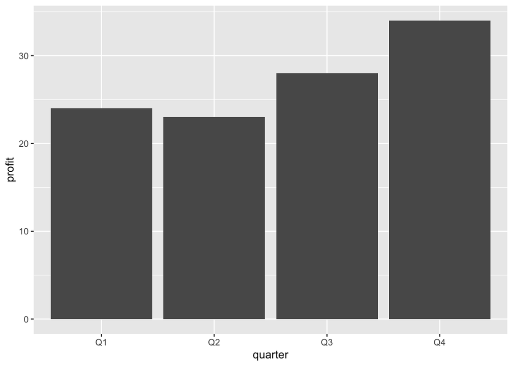

```r
ggplot(data, aes(x = quarter, y = profit)) +
  geom_col()
```

Image 1 – Simple bar chart

This one gets the job done but doesn’t look like something you’d want to show to your boss. You’ll fix it in the following sections.

# Colors and Themes

Tweaking colors and themes is the simplest thing you can do to make visualization look better. The `geom_bar()` has two useful parameters:

`color` – outline color of the bars `fill` – fill color of the bars

Here’s how to use `fill` to make your chart Appsilon-approved:

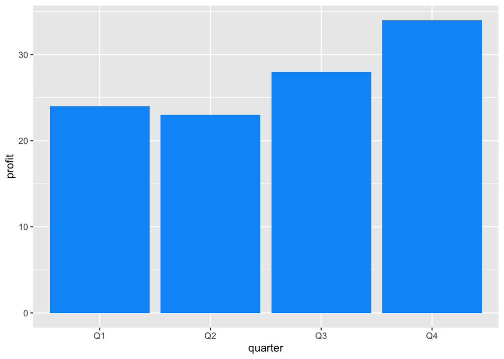

```r
ggplot(data, aes(x = quarter, y = profit)) +
  geom_col(fill = "#0099f9")
```

Image 2 – Using fill to change the bar color

The `color` parameter changes only the outline. The dataset you’re using has two distinct products. R draws a fill line between products’ values, as stacked bar charts are used by default. You’ll learn more about the stacked charts later.

Here’s what this means in practice. The code snippet below sets the fill color to white and outline color to blue:

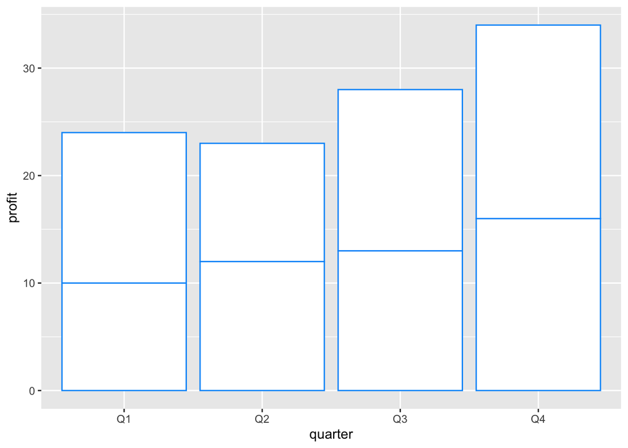

```r
ggplot(data, aes(x = quarter, y = profit)) +
  geom_col(color = "#0099f9", fill = "#ffffff")
```

Image 3 – Changing the outline color

In case coloring doesn’t do the trick, you can completely change the theme. That’s yet another layer to add after the initial visualization layer. Here’s how to do it:

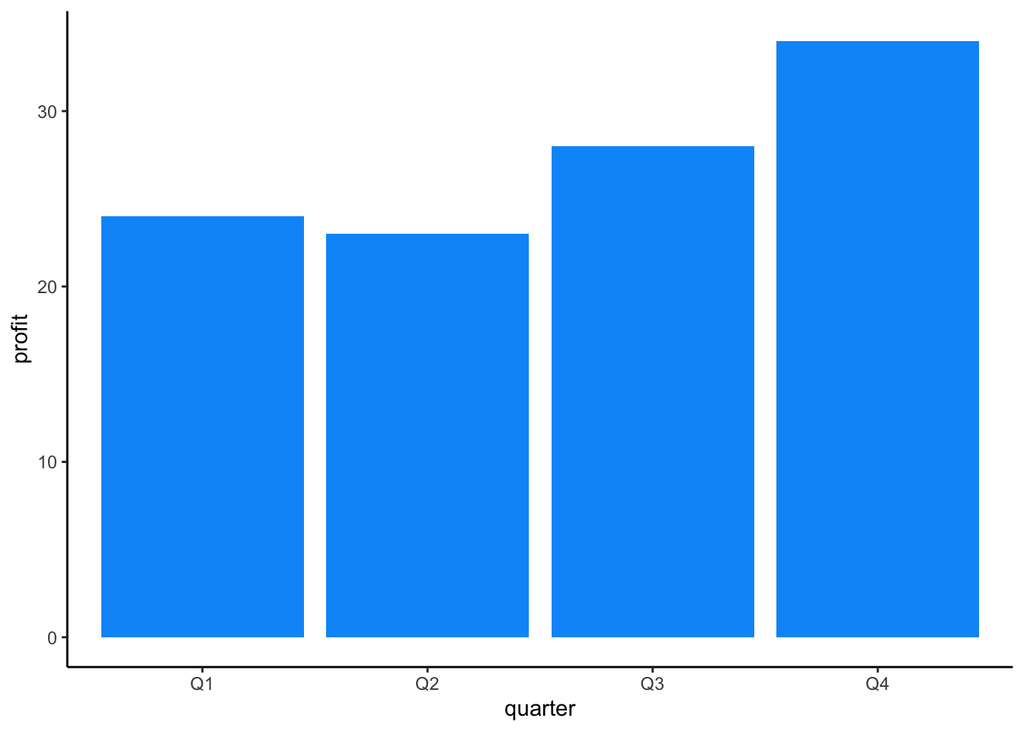

```r
ggplot(data, aes(x = quarter, y = profit)) +
  geom_col(fill = "#0099f9") +
  theme_classic()
```

Image 4 – Changing the visualization theme

If this theme isn’t your thing, there’s plenty more to pick from. You can find the entire list here.

# Titles, Subtitles, and Captions

A visualization without a title is useless. There’s no way to know if you’re looking at Election votes or 2020 USA election votes in California. You can use subtitles to put additional information, but it’s not mandatory. Captions are useful for placing visualization credits and sources.

The most convenient way to add these is through a `labs()` layer. It takes in values for `title`, `subtitle`, and `caption.` Let’s see how to add all three:

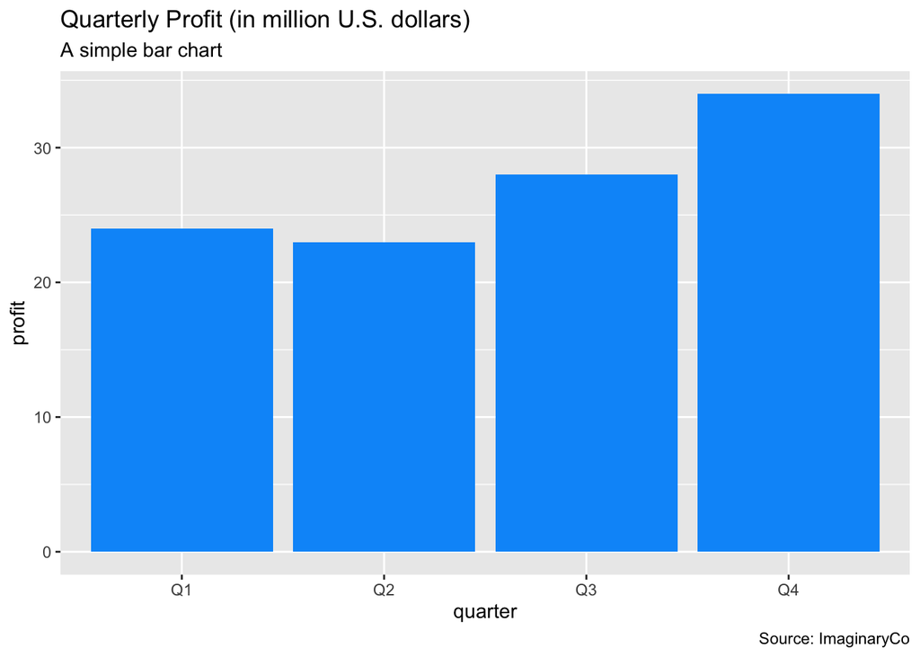

```r
ggplot(data, aes(x = quarter, y = profit)) +
  geom_col(fill = "#0099f9") +
  labs(
    title = "Quarterly Profit (in million U.S. dollars)",
    subtitle = "A simple bar chart",
    caption = "Source: ImaginaryCo"
  )
```

Image 5 – Title, subtitle, and caption with default styles

It’s a good start, but what if you want to add styles? Let’s see how to color the title, bold the subtitle, and italicize the caption:

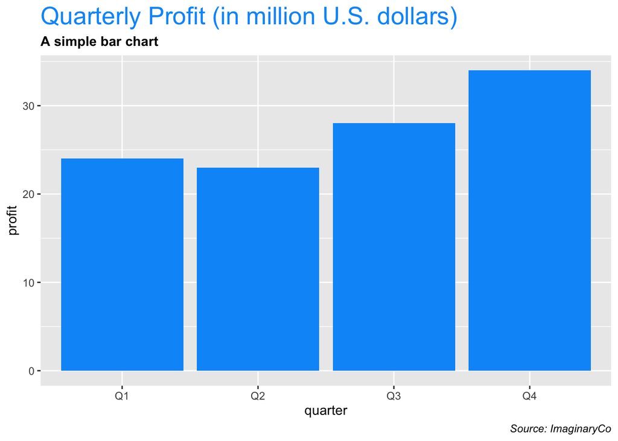

```r
ggplot(data, aes(x = quarter, y = profit)) +
  geom_col(fill = "#0099f9") +
  labs(
    title = "Quarterly Profit (in million U.S. dollars)",
    subtitle = "A simple bar chart",
    caption = "Source: ImaginaryCo"
  ) +
  theme(
    plot.title = element_text(color = "#0099f9", size = 20),
    plot.subtitle = element_text(face = "bold"),
    plot.caption = element_text(face = "italic")
  )
```

Image 6 – Styling title, subtitle, and caption

Let’s take this a step further. Here’s how to align the title to the middle, subtitle to the right, and caption to the left:

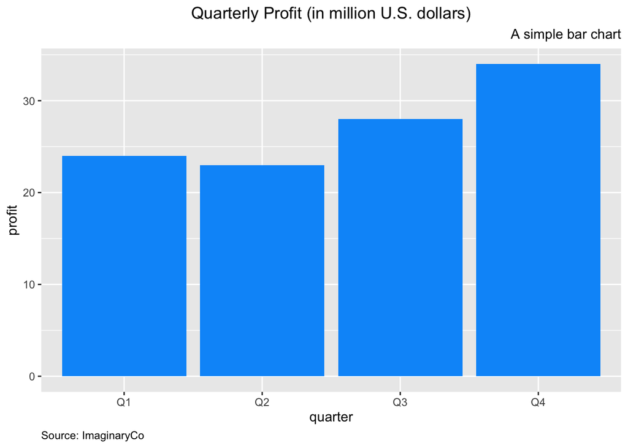

```r
ggplot(data, aes(x = quarter, y = profit)) +
  geom_col(fill = "#0099f9") +
  labs(
    title = "Quarterly Profit (in million U.S. dollars)",
    subtitle = "A simple bar chart",
    caption = "Source: ImaginaryCo"
  ) +
  theme(
    plot.title = element_text(hjust = 0.5),
    plot.subtitle = element_text(hjust = 1),
    plot.caption = element_text(hjust = 0)
  )
```

Image 7 – Aligning title, subtitle, and caption

You’ve learned how to add a nicely-formatted title, but the default axis labels still holds your visualization back. You’ll learn how to change them next.

# Axis Labels

Long story short – it works identically as with titles and subtitles. The `labs()` layer takes in values for both X and Y-axis labels. Here’s how to change the text:

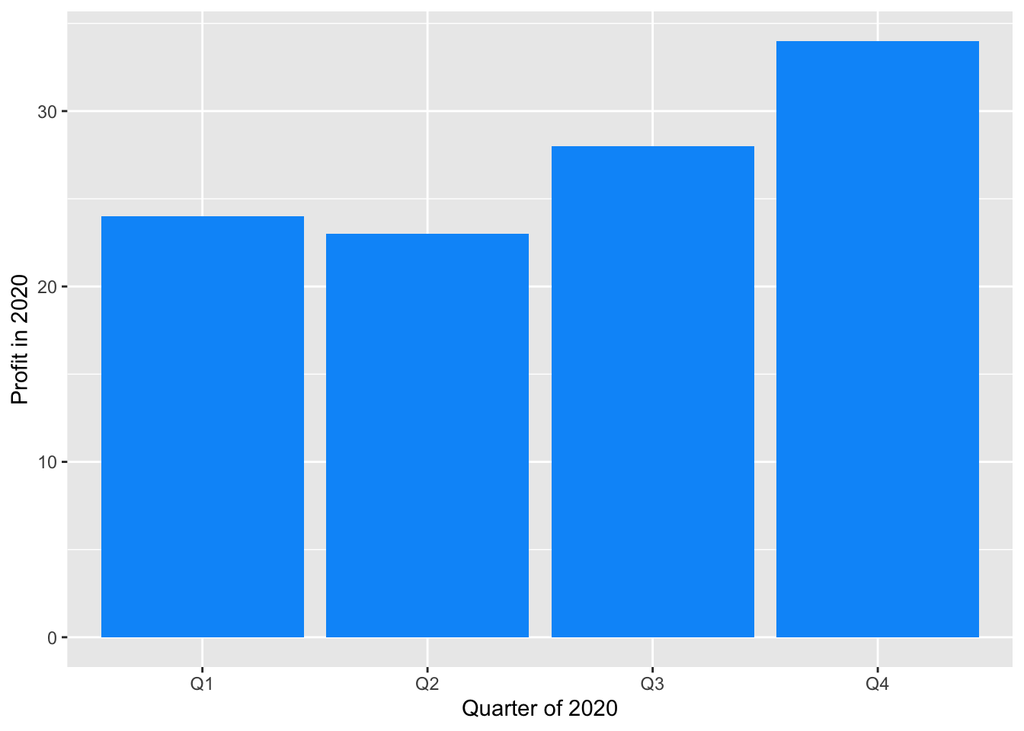

```r
ggplot(data, aes(x = quarter, y = profit)) +
  geom_col(fill = "#0099f9") +
  labs(
    x = "Quarter of 2020",
    y = "Profit in 2020"
  )
```

Image 8 – Changing X and Y axis labels

You can change the styles the same way you did with titles, subtitles, and captions. The following code snippet will make your x-axis label blue and bold, and y-axis label italic:

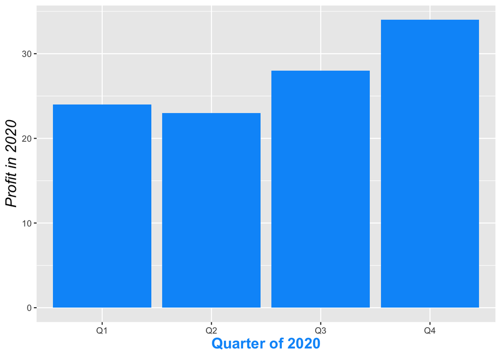

```r
ggplot(data, aes(x = quarter, y = profit)) +
  geom_col(fill = "#0099f9") +
  labs(
    x = "Quarter of 2020",
    y = "Profit in 2020"
  ) +
  theme(
    axis.title.x = element_text(color = "#0099f9", size = 15, face = "bold"),
    axis.title.y = element_text(size = 15, face = "italic")
  )
```

Image 9 – Changing stylings of X and Y axis labels

And that does it for changing the basic visuals. You’ll learn how to work with different bar charts next – stacked, grouped, and horizontal.

# Stacked, Grouped, and Horizontal Bar Charts

The `ggplot2` package uses stacked bar charts by default. Stacked bar charts are best used when all portions are colored differently.

To change the coloring, you only need to change the `fill` value in the data layer. Here’s an example:

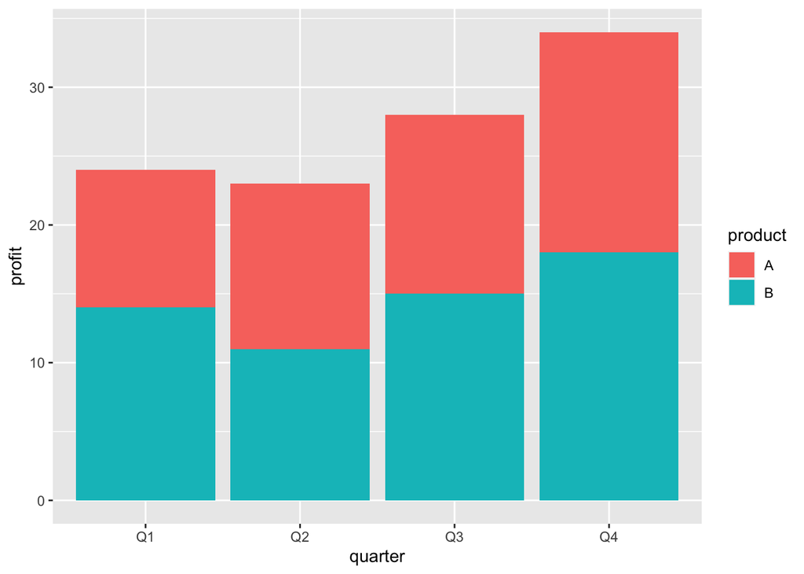

```r
ggplot(data, aes(x = quarter, y = profit, fill = product)) + geom_col()
```

Image 10 – Default stacked bar chart

There’s a visible distinction between products, and you can now see how much profit each product made quarterly.

There are two ways to change each portion’s color:

- **Manually** – by specifying a vector of color names or color hex codes
- **With palettes** – by using built-in color palettes

**Manually:** Let’s cover the manual approach first. You have to add a layer with `scale_fill_manual`:

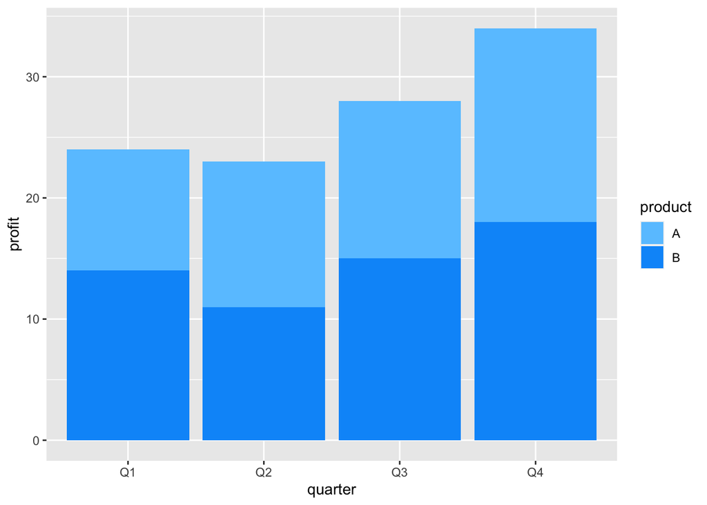

```r
ggplot(data, aes(x = quarter, y = profit, fill = product)) +
  geom_col() +
  scale_fill_manual(values = c("#69c6ff", "#0099f9"))
```

Image 11 – Stacked bar chart with custom colors

Palettes are a bit easier because you don’t need to know exact color values. For the same reason, it can also be considered as a limitation. (Here’s a list of built-in palettes: http://www.sthda.com/english/wiki/ggplot2-colors-how-to-change-colors-automatically-and-manually#use-rcolorbrewer-palettes). The `scale_fill_brewer` layer is used to work with palettes:

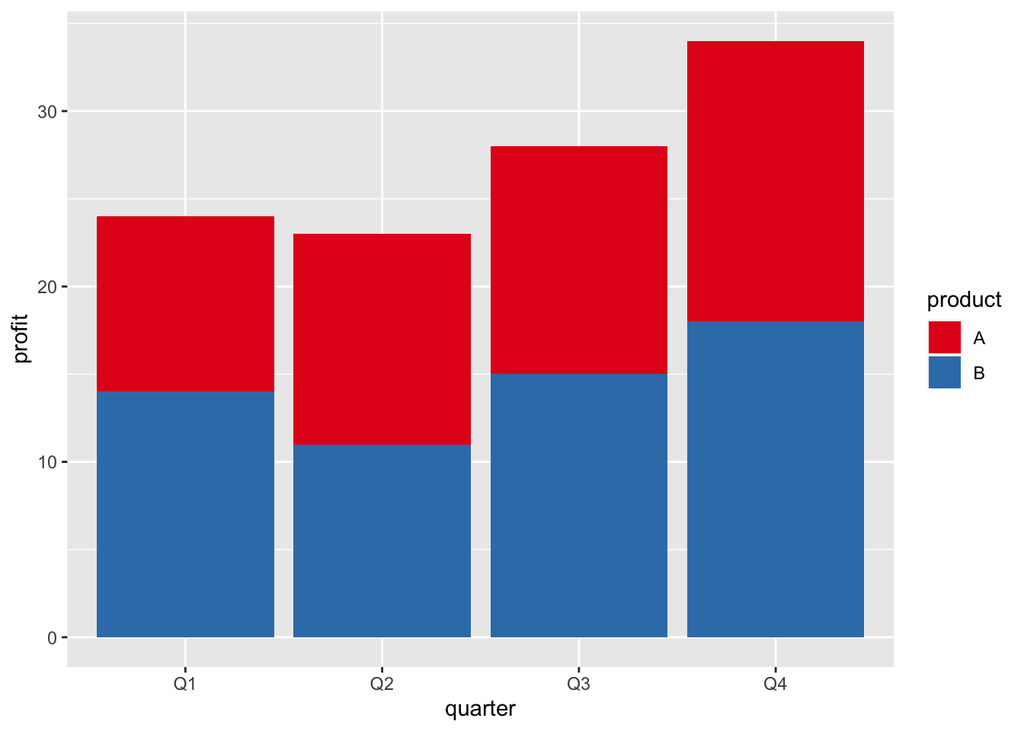

```r
ggplot(data, aes(x = quarter, y = profit, fill = product)) +
  geom_col() +
  scale_fill_brewer(palette = "Set1")
```

Image 12 – Stacked bar chart colored with a built-in palette

Onto the **grouped bar charts** now. They display bars corresponding to a group next to each other instead of on top of each other. To use grouped bar charts, you need to put `position = position_dodge()` into a `geom_bar` layer:

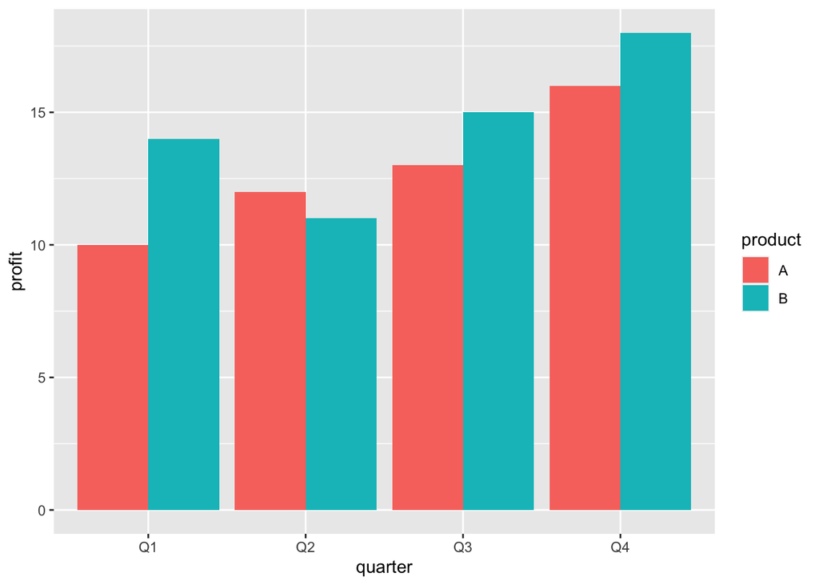

```r
ggplot(data, aes( x = quarter, y = profit, fill = product)) +
  geom_col(position = position_dodge())
```

Image 13 – Grouped bar chart (default)

You can change the coloring the same way you did with stacked bar charts – through the `scale_fill_manual` or `scale_fill_brewer` layers. Here’s an example:

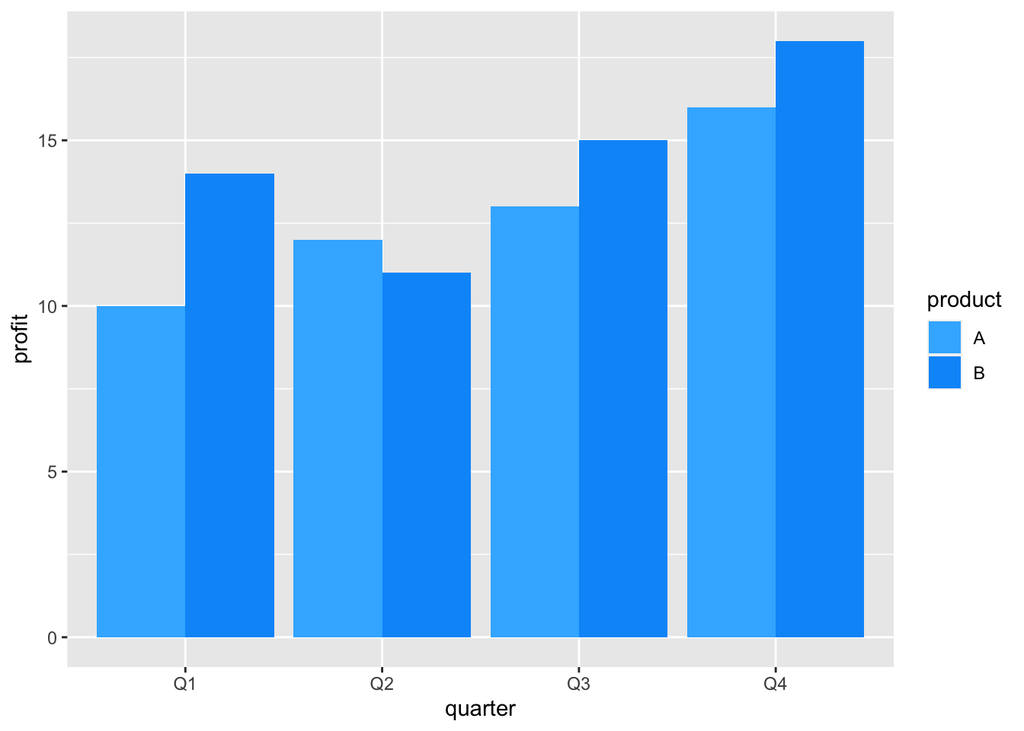

```r
ggplot(data, aes(x = quarter, y = profit, fill = product)) +
  geom_col(position = position_dodge()) +
  scale_fill_manual(values = c("#3db5ff", "#0099f9"))
```

Image 14 – Grouped bar chart with custom colors

Finally, let’s cover **horizontal bar charts**. They are useful when there are many categories on the x-axis or when their names are long. The `coord_flip()` is used to turn any vertical bar chart into a horizontal one:

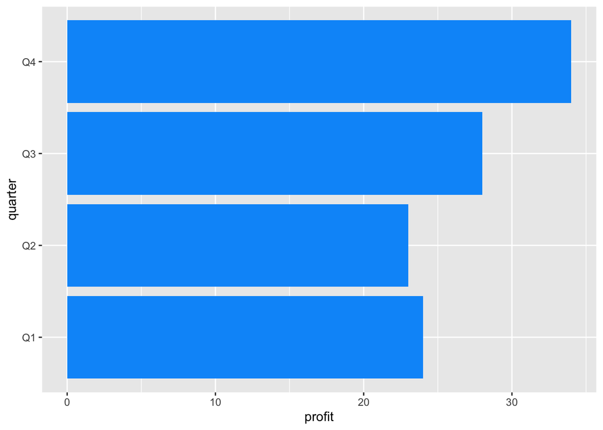

```r
ggplot(data, aes(x = quarter, y = profit)) +
  geom_col(fill = "#0099f9") +
  coord_flip()
```

Image 15 – Horizontal bar chart (default)

You can use the `scale_fill_manual` or `scale_fill_brewer` layers to change the color. Here’s an example:

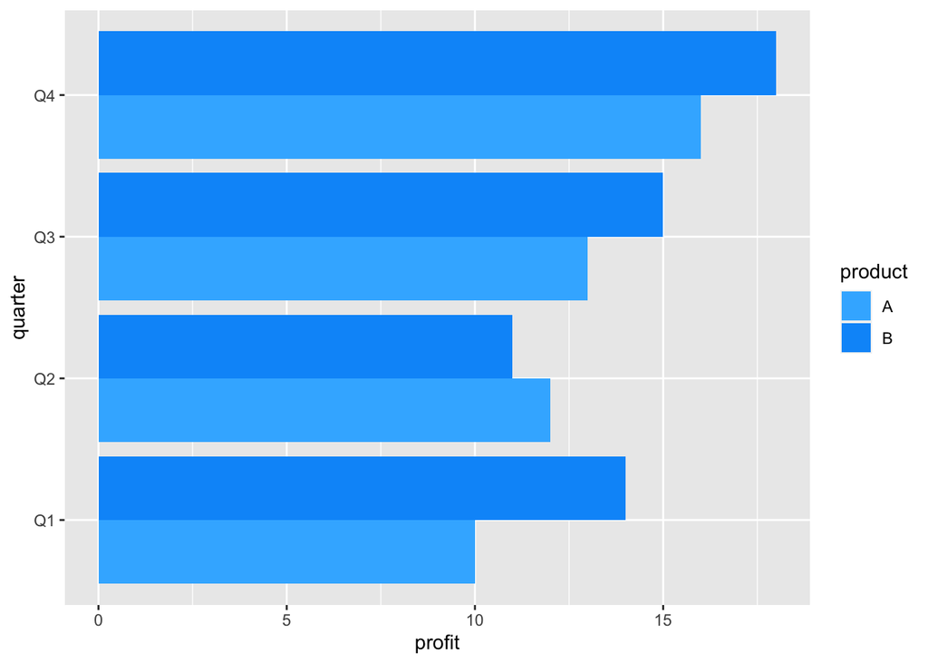

```r
ggplot(data, aes(x = quarter, y = profit, fill = product)) +
  geom_col(position = position_dodge()) +
  scale_fill_manual(values = c("#3db5ff", "#0099f9")) +
  coord_flip()
```

Image 16 – Horizontal bar chart with custom colors

Now you know how to make every type of bar chart – but there’s still one thing you can improve. Let’s see what that is in the next section.

# Labels

Bar charts can be hard to look at. Knowing the exact value is often a requirement. If the y-axis is on a scale of millions, reading values from a chart becomes an approximation (at best). That’s where labels come in.

You can put text somewhere near the top of each bar to show the exact value. That solves the problem of reading values from the chart. It also makes it more user-friendly, as you don’t have to divert your view to the y-axis constantly.

You’ll learn how to put labels on top of bars. For the first example, you’ll need to filter the dataset so only product A is shown. The reason is simple – `ggplot2` uses stacked bar charts by default, and there are two products in the stack for each quarter. You’ll learn how to add labels for multiple stacks later, but let’s start with the basics.

```r
library(dplyr)
```

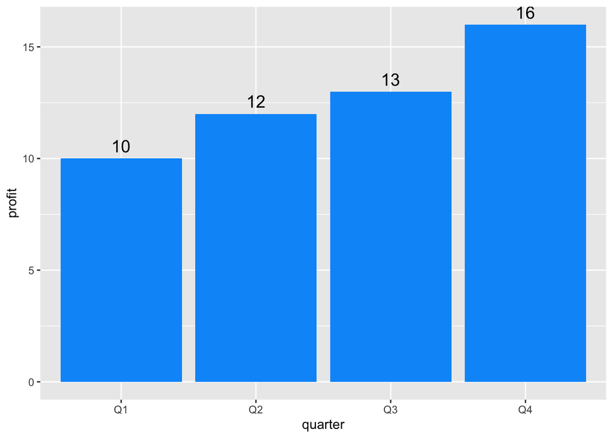

```r
data_a <- data %>%
  filter(product == "A")

ggplot(data_a, aes(x = quarter, y = profit)) +
  geom_col(fill = "#0099f9") +
  geom_text(aes(label = profit), vjust = -0.5, size = 5)
```

Image 17 – Labels on top of bars

But what if you want to put the labels inside? Just play with `vjust` a bit. Setting it to 2 does the trick:

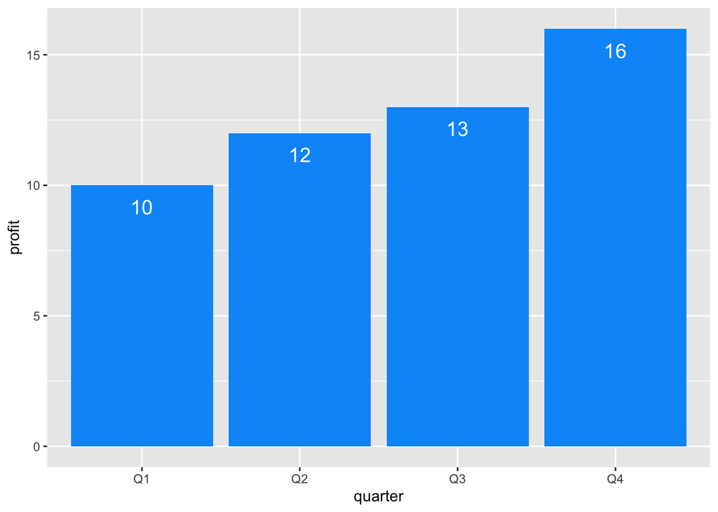

```r
ggplot(data_a, aes(x = quarter, y = profit)) +
  geom_col(fill = "#0099f9") +
  geom_text(aes(label = profit), vjust = 2, size = 5, color = "#ffffff")
```

Image 18 – Labels inside the bars

Things get a bit trickier if you need labels for multiple stacks. You have to specify `position = position_stack()` inside the `geom_text` layer. Setting the `vjust` to 0.5 makes them centered:

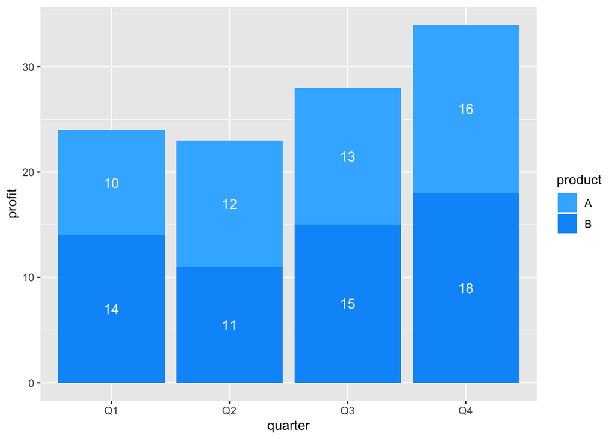

```r
ggplot(data, aes(x = quarter, y = profit, fill = product, label = profit)) +
  geom_col() +
  scale_fill_manual(values = c("#3db5ff", "#0099f9")) +
  geom_text(position = position_stack(vjust = 0.5), size = 4, color = "#ffffff")
```

Image 19 – Labels inside the stacked bar chart

There’s an alternative for a grouped bar chart. You’ll have to specify `position = position_dodge()` for it to work. This code centers the labels inside every group:

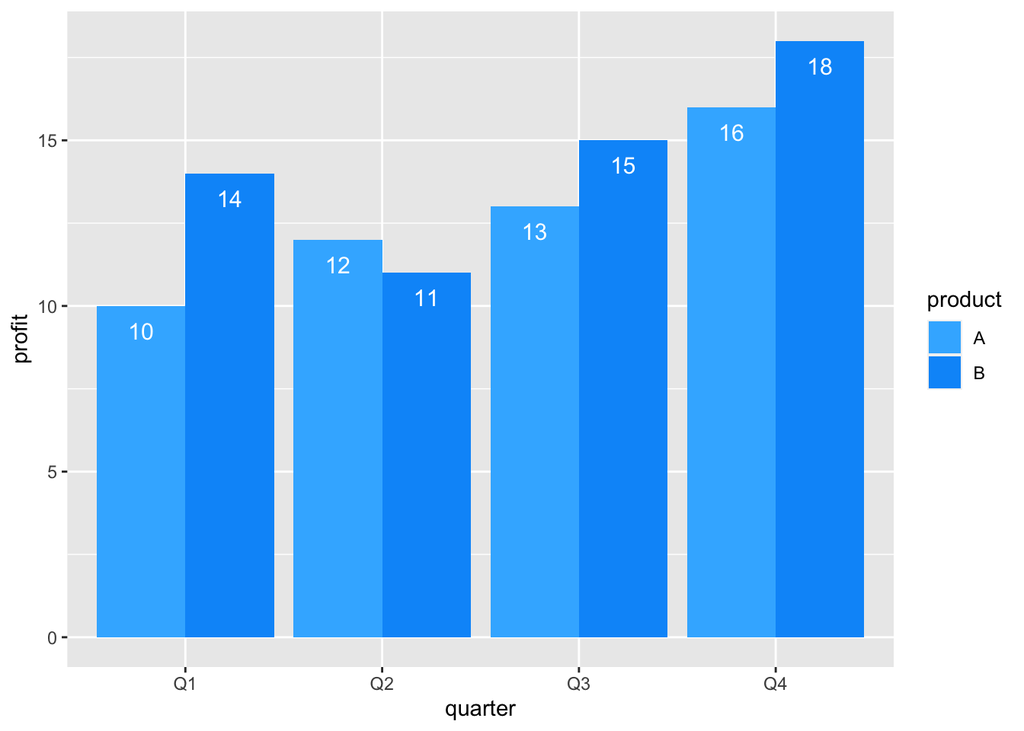

```r
ggplot(data, aes(x = quarter, y = profit, fill = product)) +
  geom_col(position = position_dodge()) +
  scale_fill_manual(values = c("#3db5ff", "#0099f9")) +
  geom_text(aes(label = profit), position = position_dodge(0.9), vjust = 2, size = 4, color = "#ffffff")
```

Image 20 – Labels centered inside the grouped bar chart

And that’s all there is about labels and bar charts. Let’s wrap things up next.

# Conclusion

Today you’ve learned how to make every type of bar chart in R and how to customize it with colors, titles, subtitles, and labels. You’re now able to use bar charts for basic visualizations, reports, and dashboards.

You can expect more basic R tutorials weekly (probably Sunday) and more advanced tutorials throughout the week. Fill out the subscribe form below so you never miss an update.